# Deliverable 1: Project Plan

Practicum Spring 2024

2024-02-01

# Workforce Housing in Watauga County, NC

## Project Scope

Watauga County, North Carolina, is currently experiencing a housing shortage that is expected to intensify in the near future. The shortage is exacerbated by vacation rentals and student housing, which has significantly reduced the available residential housing options. Currently, there is no streamlined system in place to help identify suitable parcels for development. In response to this issue, the Watauga Housing Council has contracted us to develop an application-based data framework that is designed to identify land parcels based on their likelihood to be developed for affordable and workforce housing. This data framework will be designed to function as an interactive application interface that will allow users to input criteria related to land supply and combine it with development likelihood estimates to rank each parcel in the county in terms of suitability. We will use the administrative record associated with a septic system permit as the key indicator for development. This permit is exclusively granted when a property satisfies the requirements for both land supply and developer demand at that specific site. Our approach will involve identifying the site suitability characteristics (e.g., slope, soils) most closely related to the probability of a parcel receiving a septic permit. Subsequently, we will forecast the likelihood that a given parcel will receive a new septic permit application in the next ten years based on the analysis of the previous ten years of permits.

## Project Objectives

- Identify the features that influence septic permit receival.
- Create a model that can predict to a degree of certainty which parcels will receive a septic permit.
- Create a data framework that identifies parcels based on their estimated likelihood of being developed.
- Create a interactive user interface application where the user can search land parcels based on input criteria related to land supply.

*Goals can be further broken down into phases:*

**Exploratory Analysis**

- Understand the current state of housing and affordability, development trends, and demographics in Watauga and surrounding countries.
- Identify the characteristics of properties that are sold in the County.
- Data wrangling – Collect data that influences.
- Collect septic system permit data and Identify the features that influence the approval process.

**Modeling**

- Test and finalize model predictors.
- Figure out temporal construction of the model.
- Validate model.

**App Development**

- Create app wireframe.
- Develop app.
- Test app function.

## Project Schedule

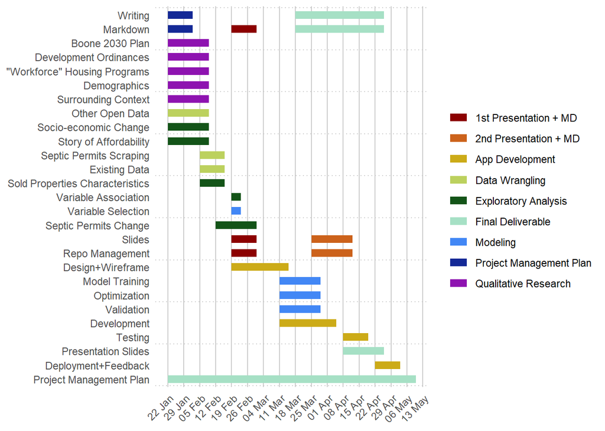

## Risk Management

Potential risks we may encounter include:

- Issues with code and modeling (optimization, validation, etc.)
- Issues with app development and user interface
- Possible issues with knitting

## Communication Plan

**Internal communication**: Whatsapp/Email for messaging. Plan to meet on Thursdays outside of class for collaborative working hours.

**Client communication**: initial meeting + interview held over zoom, other communication largely held over email.

## Stakeholder Management

Watauga Housing Council: (Kellie Reed Ashcraft, Laura Beach, Chris Quattro (Appalachian State University)): Main project client, this organization is tasked with responding to the economic, environmental, and social aspects of the county to provide adequate housing options for all residents. AppHealthCare (Andrew Blethen, Jason Pierce): besides their widely-known health-related services, this organization is also tasked with operating the permitting of septic and water infrastructure in the County.

## Change Management

Because we developed an initial project plan, complete with deadlines, deliverables, and tasks, it will be more clear and opaque on how to address updates that may come up. Each week, we will evaluate our progress against the Project Plan, readjusting deadlines and aspects of the deliverables as appropriate. Maintaining flexibility while staying on task will be crucial to a successful project.

## Team Roles + Responsibilities

**Project Managers** (*Jarred, Kathleen*) - Keeps team members on task and accountable Leads team sprints Manages communications

**Markdown + Github Lead*** - (*Jingyi, Kathleen*) - Keeps team markdown updated Publishes md / rmd for professor review each week

**JS Engineering Lead** - (*Alice, Yinan*) - Leads app development

**Model Engineering Lead** - *Jingyi*

**Lead Researcher** - *Jarred*

**Exploratory Analysis Lead** - *Yinan*

**Lead Writer** - *Kathleen*

## Monitoring + Evaluation

We are in the process of developing a comprehensive project task list, which will include a detailed breakdown of the project scope, outlining all major objectives and their corresponding subtasks. We will conduct weekly review meetings where we will discuss the progress of each task in conjunction with the project schedule. This will ensure that we remain on track with the projected deadlines and allows us to make any necessary adjustments to keep the project aligned with our goals.

## Closure + Documentation

We will develop a project closeout checklist that will outline all necessary steps for creating the final deliverables and documentation. Once the checklist is finalized, we will assign specific tasks to each team member and collaborate to ensure the completion of all necessary activities. Additionally, we have allocated a sufficient amount of time to facilitate the development and completion of all tasks involved in the project closeout process.